# Lista 1 – Respostas

Probabilidade e Estatística – 2020.1

fnaufel

02/12/2020 (modificado em 22/09/2021)

# 1 Visualização

## 1.1 Peso cerebral

Usando o conjunto de dados `msleep`, construa um histograma da variável `brainwt`. Escolha o número de classes que você achar melhor. O que acontece com os valores `NA`?

### Solução

- Carregando o dataframe:

  ```r
  sono <- msleep
  ```

- Vamos ver algumas medidas de `brainwt` para decidir o número de barras no histograma:

  ```r
  summary(sono$brainwt)
  ```

  ```
  ##    Min. 1st Qu.  Median    Mean 3rd Qu.    Max.    NA's
  ## 0,00014 0,00290 0,01240 0,28158 0,12550 5,71200      27
  ```

- Aproximadamente de $0$ a $6$kg. Vamos usar divisões de $0{,}5$kg:

  ```
  ## Warning: Removed 27 rows containing non-finite values (stat_bin).
  ```

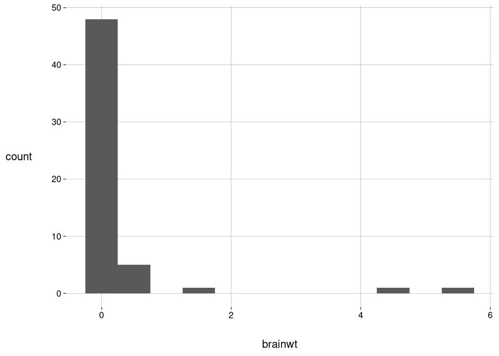

  ```r
  sono %>%
    ggplot(aes(x = brainwt)) +
      geom_histogram(binwidth = .5)
  ```

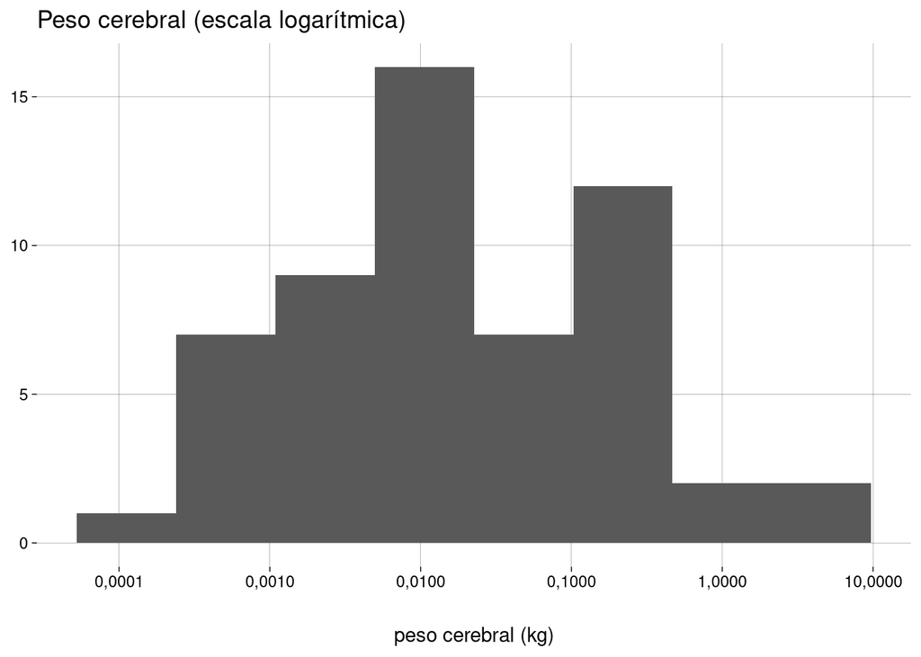

  ```r
  sono %>%
    ggplot(aes(x = brainwt)) +
      geom_histogram(bins = 8) +
      scale_x_log10(breaks = waiver(), n.breaks = 6) +
      labs(
        y = NULL,
        x = 'peso cerebral (kg)',
        title = 'Peso cerebral (escala logarítmica)'
      )
  ```

- Agora melhorou. Note que os valores do eixo $x$ continuam sendo em kg.
- A barra com mais animais é a de peso cerebral em volta de $0{,}01$kg, ou $10$g.
- Podemos também transformar os valores de peso cerebral no conjunto de dados e verificar que os logaritmos destes valores seguem uma distribuição aproximadamente normal:

  ```r
  sonolog <- sono %>%
    mutate(bwlog = log10(brainwt))
  ```

  ```r
  (mu_bwlog <- mean(sonolog$bwlog, na.rm = TRUE));
  ```

  ```
  ## [1] -1,764449
  ```

  ```r
  (sd_bwlog <- sd(sonolog$bwlog, na.rm = TRUE))
  ```

  ```
  ## [1] 1,098002
  ```

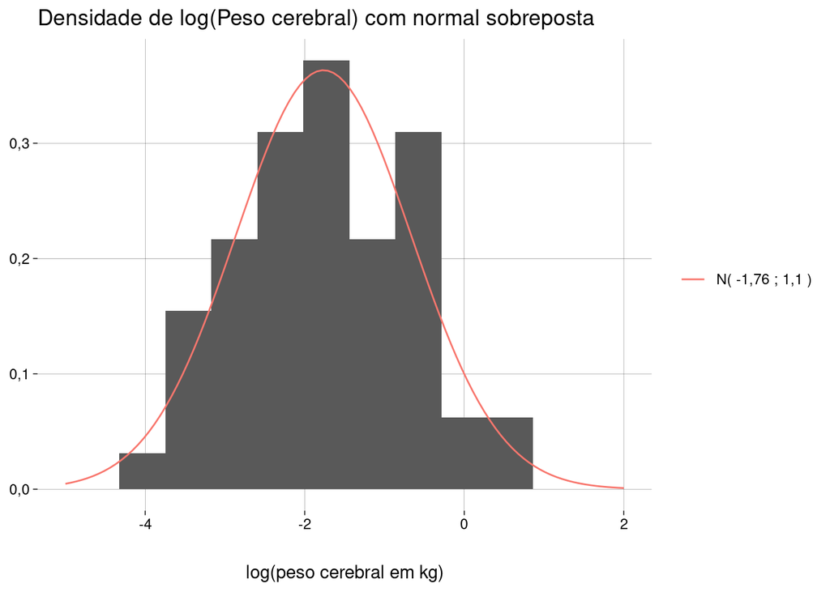

  ```r
  nobs <- sum(!is.na(sonolog$bwlog))

  nbins <- 8

  bw <- (
    max(sonolog$bwlog, na.rm = TRUE)
    -
    min(sonolog$bwlog, na.rm = TRUE)
  ) / nbins


  sonolog %>%
    ggplot(aes(x = bwlog)) +
      geom_histogram(
        aes(y = after_stat(density)),
        binwidth = bw
      ) +
      labs(
        y = NULL,
        x = 'log(peso cerebral em kg)',
        title = 'Densidade de log(Peso cerebral) com normal sobreposta',
        color = NULL
      ) +
      stat_function(
        mapping = aes(
          color = paste(
            'N(',
            round(mu_bwlog, 2),
            ';',
            round(sd_bwlog, 2),
            ')'
          )
        ),
        fun = function(x) {
          dnorm(
            x,
            mean = mu_bwlog,
            sd = sd_bwlog
          )
        },
        xlim = c(-5, 2)
      )
  ```

- Preste atenção em uma sutileza: a curva normal *sempre* tem área $1$ abaixo dela. Então, para sobrepor esta normal ao histograma, mudamos o eixo $y$ para a *densidade* (em vez da *quantidade*) de animais em cada barra, para igualar a escala das barras com a escala da normal. Ou seja, a área total das barras passou a ser igual a $1$, assim como a área abaixo da normal. Examine o código R para ver as mudanças.
- Quando os *logaritmos* de um conjunto de valores seguem uma distribuição normal, dizemos que o conjunto de valores *originais* segue uma distribuição *lognormal*.
- Um QQPlot com os logaritmos padronizados (usando `scale`):

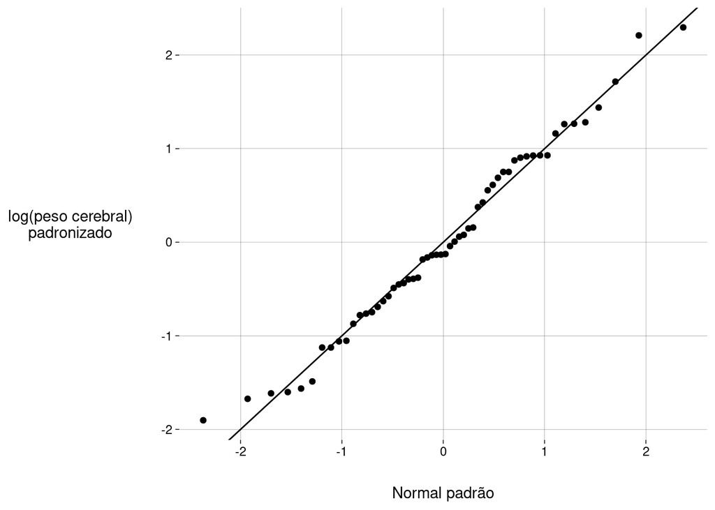

  ```r
  sonolog %>%
    ggplot() +
      geom_qq(aes(sample = scale(bwlog))) +
      geom_abline() +
      labs(
        x = 'Normal padrão',
        y = 'log(peso cerebral)\npadronizado'
      )
  ```

## 1.2 Horas de sono $\times$ peso cerebral

Usando o conjunto de dados `msleep`, construa um *scatter plot* de horas de sono versus peso cerebral. Você percebe alguma correlação entre estas variáveis? Se precisar, concentre-se em um subconjunto dos dados.

### Solução

- Gráfico:

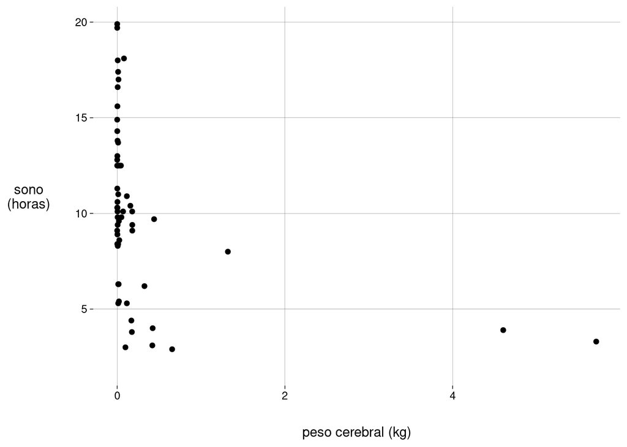

  ```r
  sono %>%
    ggplot(aes(x = brainwt, y = sleep_total)) +
      geom_point() +
      labs(
        y = 'sono\n(horas)',
        x = 'peso cerebral (kg)'
      )
  ```

- De novo, os $3$ animais de maior peso cerebral atrapalham. Vamos ignorá-los.

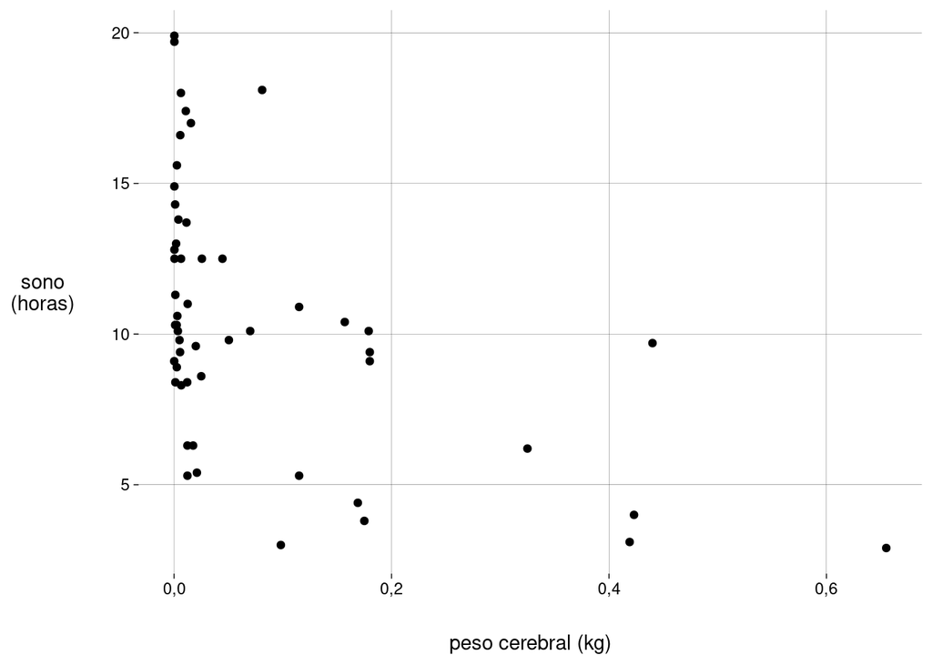

  ```r
  sono %>%
    slice_min(
      order_by = brainwt,
      n = sum(!is.na(.$brainwt)) - 3
    ) %>%
    ggplot(aes(x = brainwt, y = sleep_total)) +
      geom_point() +
      labs(
        y = 'sono\n(horas)',
        x = 'peso cerebral (kg)'
      )
  ```

- Nesta amostra, existe uma pequena correlação negativa entre peso cerebral e horas de sono: quanto mais pesado o cérebro do animal, menos horas de sono ele dorme.
- Claro que esta amostra é pouco representativa de mamíferos em geral — só considera um número reduzido de animais pequenos.
- Além disso, provavelmente existem outras variáveis, além de peso cerebral, que afetam o número de horas de sono.

# 2 Medidas

## 2.1 Valor médio e desvio padrão de lançamentos de um dado

- Simule 10 mil lançamentos de um dado não-viciado.
- Calcule a média dos valores obtidos.
- Faça um gráfico (como o do primeiro vídeo sobre probabilidades) do valor médio em função do número do lançamento (i.e., considerando todos os lançamentos anteriores).

### Solução

- Gráficos:

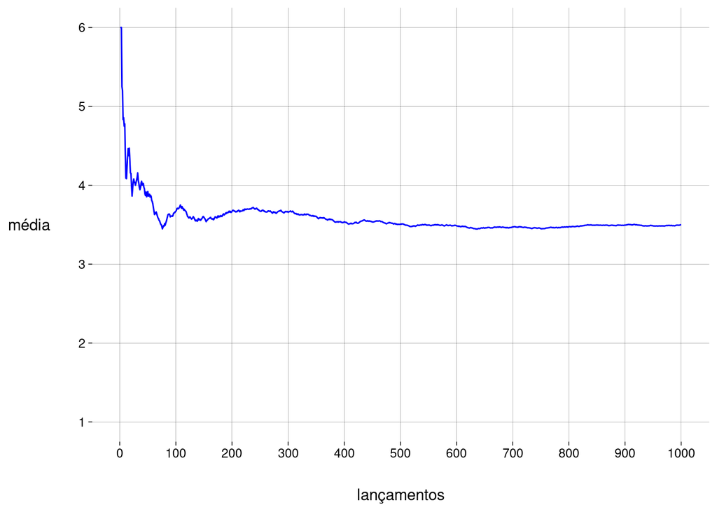

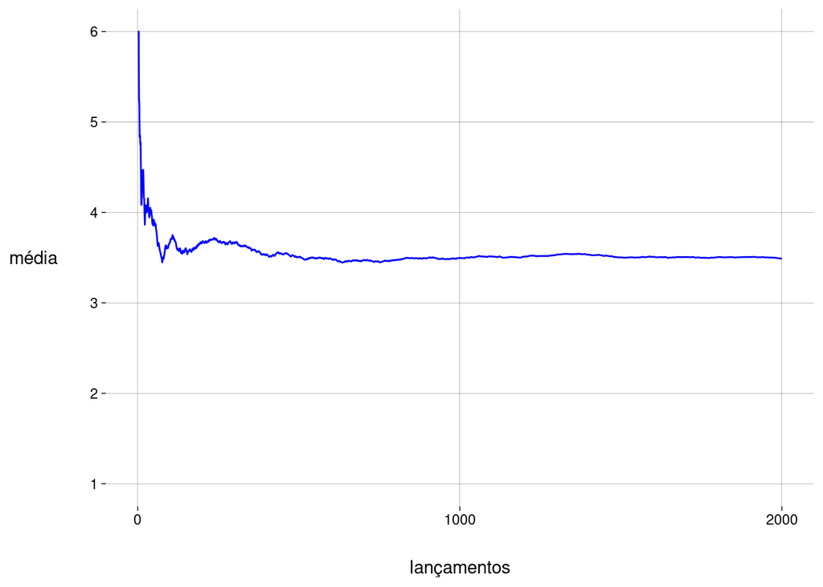

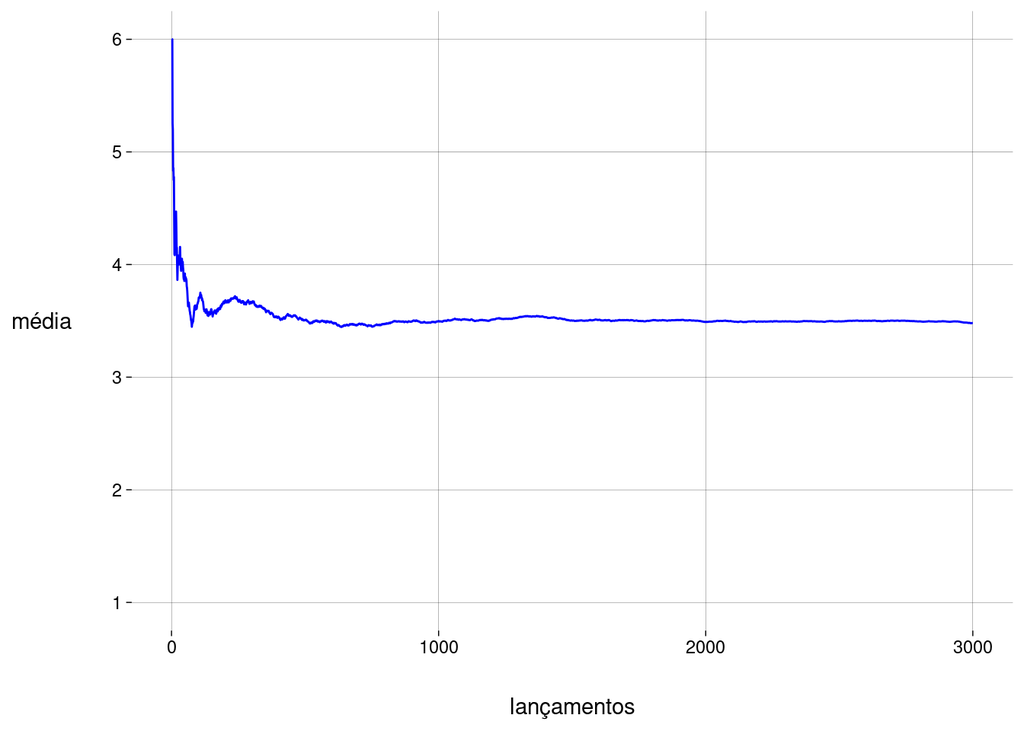

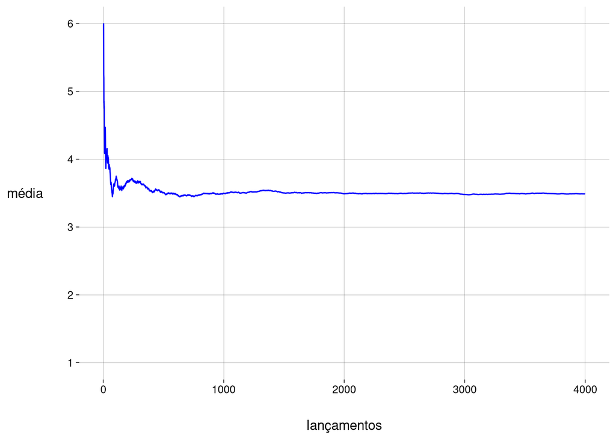

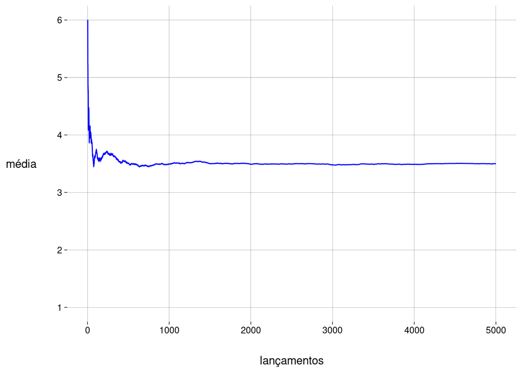

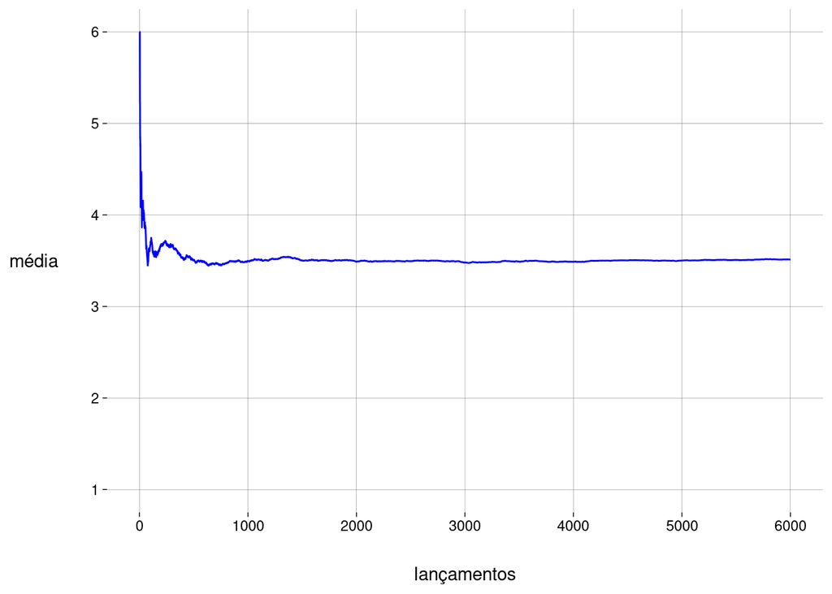

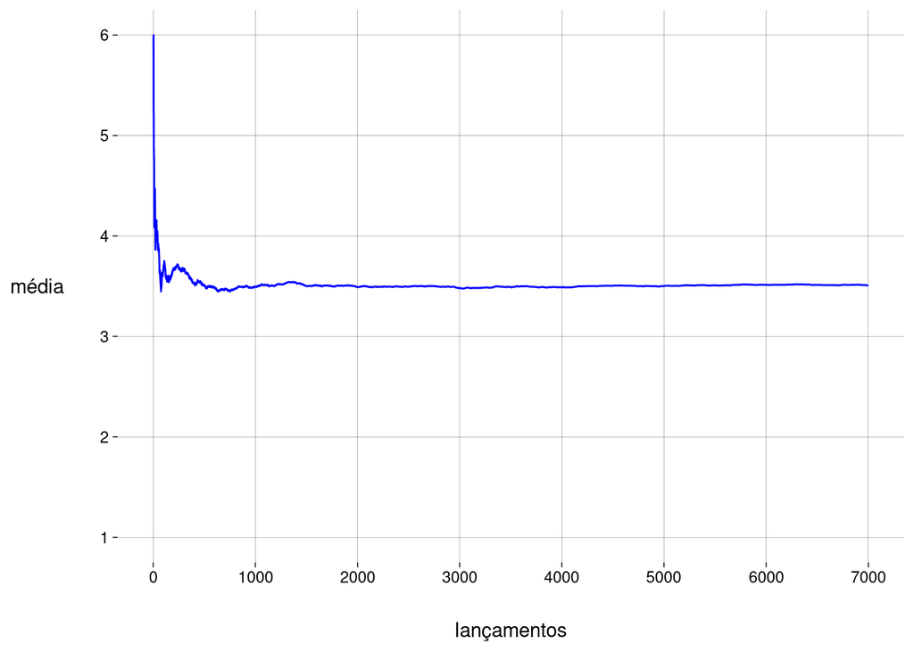

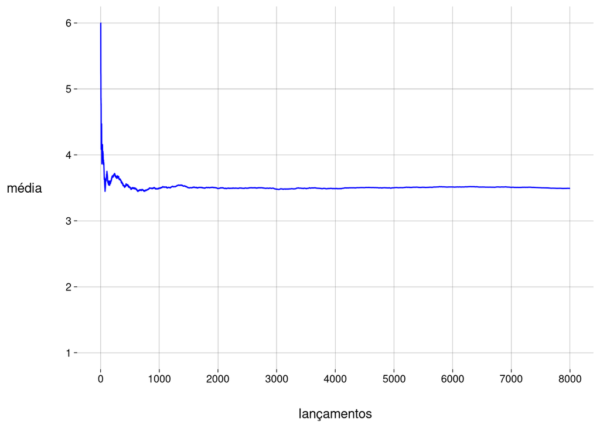

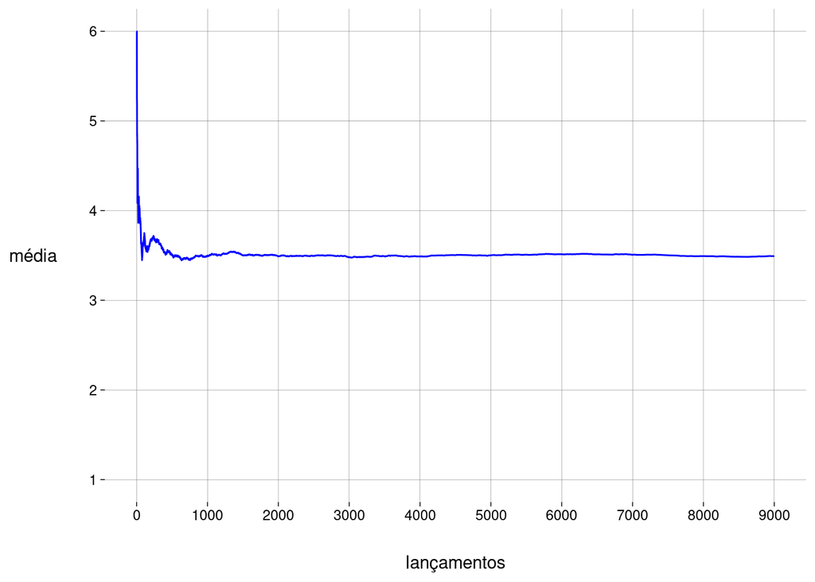

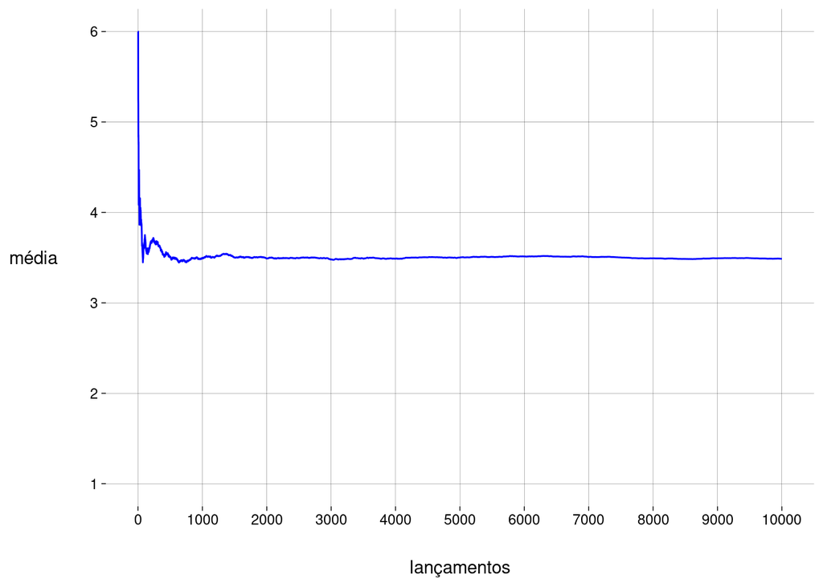

  ```r
  dado <- 1:6
  lancamentos <- tibble(
    resultado = sample(dado, 1e4, replace = TRUE),
    linha = 1:length(resultado),
    media_acum = cumsum(resultado) / linha
  )

  plotar_n_primeiros <- function(n) {

    intervalo <- 10 ^ (ceiling(log10(n)) - 1)

    grafico <- lancamentos %>%
      select(media_acum) %>%
      slice_head(n = n) %>%
      ggplot(aes(x = 1:n, y = media_acum)) +
        geom_line(color = 'blue') +
        scale_y_continuous(
          name = 'média',
          limits = c(1, 6),
          breaks = 1:6
        ) +
        scale_x_continuous(
          name = 'lançamentos',
          breaks = seq(0, n, intervalo)
        )

    print(grafico)

  }

  walk(
    seq(1e3, 1e4, 1e3),
    plotar_n_primeiros
  )
  ```

## 2.2 Valores discrepantes

- Escreva uma função que receba um vetor numérico e retorne um vetor contendo os *outliers* segundo a definição usada para construir *boxplots*.

### Solução

- A *amplitude interquartil (IQR)* é a diferença entre o terceiro quartil e o primeiro quartil dos dados.
- Os *outliers* são aqueles elementos que
  - estão a uma distância maior do que $1{,}5 \cdot \text{IQR}$ acima do terceiro quartil, ou
  - estão a uma distância maior do que $1{,}5 \cdot \text{IQR}$ abaixo do primeiro quartil.

    ```r
    outliers <- function(x) {

      # Decidi incluir a mediana só para quartil[3] ser o terceiro quartil
      quartil <- quantile(x, c(.25, .5, .75))
      margem <- IQR(x) * 1.5

      limite_inf <- quartil[1] - margem
      limite_sup <- quartil[3] + margem

      # Imprimir só para sabermos o que foi calculado
      cat(
        glue::glue(
          'Limite inf: {limite_inf}\n',
          'Limite sup: {limite_sup}\n\n'
        )
      )

      x[which(x < limite_inf | x > limite_sup)]

    }
    ```

    ```r
    # Exemplo de https://en.wikipedia.org/wiki/Box_plot#Example_without_outliers
    x <- c(57, 57, 57, 58, 63, 66, 66, 67, 67, 68, 69, 70, 70, 70, 70, 72, 73, 75, 75, 76, 76, 78, 79, 81)

    outliers(x)
    ```

    ```
    ## Limite inf: 52,5
    ## Limite sup: 88,5
    ```

    ```
    ## numeric(0)
    ```

    ```r
    # Exemplo de https://en.wikipedia.org/wiki/Box_plot#Example_with_outliers
    x <- c(52, 57, 57, 58, 63, 66, 66, 67, 67, 68, 69, 70, 70, 70, 70, 72, 73, 75, 75, 76, 76, 78, 79, 89)

    outliers(x)
    ```

    ```
    ## Limite inf: 52,5
    ## Limite sup: 88,5
    ```

    ```
    ## [1] 52 89
    ```

- Escreva uma função que receba um vetor numérico e retorne um vetor contendo os valores que estão a 2 ou mais desvios padrão de distância da média.

### Solução

- Função:

  ```r
  longe_da_media <- function(x, n = 2) {

    media <- mean(x)
    dp <- sd(x)

    limite_inf <- media - n * dp
    limite_sup <- media + n * dp

    # Imprimir só para sabermos o que foi calculado
    cat(
      glue::glue(
        'Limite inf: {limite_inf}\n',
        'Limite sup: {limite_sup}\n\n'
      )
    )

    x[which(x < limite_inf | x > limite_sup)]

  }
  ```

- Ache um exemplo de vetor numérico que faça as duas funções retornar o mesmo resultado.

### Solução

- O último exemplo serve:

  ```r
  outliers(x)
  ```

  ```
  ## Limite inf: 52,5
  ## Limite sup: 88,5
  ```

  ```
  ## [1] 52 89
  ```

  ```r
  longe_da_media(x)
  ```

  ```
  ## Limite inf: 52,9318094687498
  ## Limite sup: 85,6515238645835
  ```

  ```
  ## [1] 52 89
  ```

## 2.3 Denominador $n - 1$ na variância amostral

- Escreva uma função `varpop` que recebe um vetor numérico e calcula a variância *populacional* (usando a fórmula com $N$ no denominador).

### Solução

- Função:

  ```r
  varpop <- function(v) {

    N <- length(v)
    var(v) * (N - 1) / N

  }
  ```

- Considere o vetor `populacao` abaixo:

  ```r
  populacao <- c(1, 4, 10, 15)
  ```

- Calcule a variância *populacional*, usando a sua função `varpop`.

### Solução

- Chamando nossa função:

  ```r
  var_populacional <- varpop(populacao)
  var_populacional
  ```

  ```
  ## [1] 29,25
  ```

- Carregue o pacote `RcppAlgos`. Instale-o se necessário.
- Gere todos os arranjos possíveis de 3 elementos desta população, *com reposição*. Use a função `permuteGeneral`. O resultado vai ser uma matriz com 64 linhas. Cada linha corresponde a uma amostra.

  ```r
  library(RcppAlgos)

  amostras <- permuteGeneral(
    populacao,
    m = 3,
    repetition = TRUE
  )

  amostras
  ```

  ```
  ##       [,1] [,2] [,3]
  ##  [1,]    1    1    1
  ##  [2,]    1    1    4
  ##  [3,]    1    1   10
  ##  [4,]    1    1   15
  ##  [5,]    1    4    1
  ##  [6,]    1    4    4
  ##  [7,]    1    4   10
  ##  [8,]    1    4   15
  ##  [9,]    1   10    1
  ## [10,]    1   10    4
  ## [11,]    1   10   10
  ## [12,]    1   10   15
  ## [13,]    1   15    1
  ## [14,]    1   15    4
  ```

  [output cut: 50 more lines]

- **(Variâncias amostrais com denominador $n$)** Para cada amostra, calcule a variância *usando a sua função `varpop`*, guardando os resultados em um vetor. Use a função `apply`, do R base.
  - Quantas destas variâncias são menores ou iguais à variância da população inteira? Quantas são maiores?
  - Calcule a média das variâncias obtidas. O resultado é maior ou menor do que a variância populacional? Usar $n$ no denominador da variância amostral superestima ou subestima a variância da população?

### Solução

- Variâncias:

  ```r
  var_amostras_N <- apply(amostras, 1, varpop)
  var_amostras_N
  ```

  ```
  ##  [1]  0,000000  2,000000 18,000000 43,555556  2,000000  2,000000 14,000000
  ##  [8] 36,222222 18,000000 14,000000 18,000000 33,555556 43,555556 36,222222
  ## [15] 33,555556 43,555556  2,000000  2,000000 14,000000 36,222222  2,000000
  ## [22]  0,000000  8,000000 26,888889 14,000000  8,000000  8,000000 20,222222
  ## [29] 36,222222 26,888889 20,222222 26,888889 18,000000 14,000000 18,000000
  ## [36] 33,555556 14,000000  8,000000  8,000000 20,222222 18,000000  8,000000
  ## [43]  0,000000  5,555556 33,555556 20,222222  5,555556  5,555556 43,555556
  ## [50] 36,222222 33,555556 43,555556 36,222222 26,888889 20,222222 26,888889
  ## [57] 33,555556 20,222222  5,555556  5,555556 43,555556 26,888889  5,555556
  ## [64]  0,000000
  ```

  ```r
  cat(
    glue::glue(
      '. Menores ou iguais: {sum(var_amostras_N <= var_populacional)}\n',
      '.           Maiores: {sum(var_amostras_N > var_populacional)}'
    )
  )
  ```

  ```
  ## . Menores ou iguais: 46
  ## .           Maiores: 18
  ```

  ```r
  mean(var_amostras_N)
  ```

  ```
  ## [1] 19,5
  ```

- A média das variâncias obtidas é *menor* do que a variância da população. Usar $n$ no denominador *subestima* a variância da população.
- **(Variâncias amostrais com denominador $n - 1$)** Agora, para cada amostra, calcule a variância *amostral* (com $n-1$ no denominador), guardando os resultados em outro vetor. Use a função `apply`, do R base.
  - Quantas destas variâncias são menores ou iguais à variância da população inteira? Quantas são maiores?
  - Calcule a média das variâncias obtidas. O resultado é maior ou menor do que a variância populacional?

### Solução

- Variâncias:

  ```r
  var_amostras_N_1 <- apply(amostras, 1, var)
  var_amostras_N_1
  ```

  ```
  ##  [1]  0,000000  3,000000 27,000000 65,333333  3,000000  3,000000 21,000000
  ##  [8] 54,333333 27,000000 21,000000 27,000000 50,333333 65,333333 54,333333
  ## [15] 50,333333 65,333333  3,000000  3,000000 21,000000 54,333333  3,000000
  ## [22]  0,000000 12,000000 40,333333 21,000000 12,000000 12,000000 30,333333
  ## [29] 54,333333 40,333333 30,333333 40,333333 27,000000 21,000000 27,000000
  ## [36] 50,333333 21,000000 12,000000 12,000000 30,333333 27,000000 12,000000
  ## [43]  0,000000  8,333333 50,333333 30,333333  8,333333  8,333333 65,333333
  ## [50] 54,333333 50,333333 65,333333 54,333333 40,333333 30,333333 40,333333
  ## [57] 50,333333 30,333333  8,333333  8,333333 65,333333 40,333333  8,333333
  ## [64]  0,000000
  ```

- Quantas destas variâncias são menores ou iguais à variância da população inteira? Quantas são maiores?

  ```r
  cat(
    glue::glue(
      '. Menores ou iguais: {sum(var_amostras_N_1 <= var_populacional)}\n',
      '.           Maiores: {sum(var_amostras_N_1 > var_populacional)}'
    )
  )
  ```

  ```
  ## . Menores ou iguais: 34
  ## .           Maiores: 30
  ```

- Calcule a média das variâncias obtidas. O resultado é maior ou menor do que a variância populacional?

  ```r
  mean(var_amostras_N_1)
  ```

  ```
  ## [1] 29,25
  ```

- O resultado é *igual* à variância populacional!

# 3 Probabilidades

## 3.1 Titanic

### Solução

- Montando a tabela:

  ```r
  tit_tab <- Titanic %>%
    ftable(row.vars = 'Survived', col.vars = 'Class') %>%
    as.table() %>%
    addmargins()

  dimnames(tit_tab) <- list(
      'Sobrev' = c('N', 'S', 'Total'),
      'Classe' = c('1a', '2a', '3a', 'Trip', 'Total')
    )

  tit_tab
  ```

  ```
  ##        Classe
  ## Sobrev    1a   2a   3a Trip Total
  ##   N      122  167  528  673  1490
  ##   S      203  118  178  212   711
  ##   Total  325  285  706  885  2201
  ```

- Qual a probabilidade de um tripulante sobreviver?

  I.e., a probabilidade de alguém sobreviver, dado que é tripulante:

  $$P(\text{sobreviver} \mid \text{tripulante}) =
  P(\text{tripulante} \cap \text{sobreviver}) / P(\text{tripulante})$$

  ```r
  tit_tab['S', 'Trip'] / tit_tab['Total', 'Trip']
  ```

  ```
  ## [1] 0,239548
  ```

- Qual a probabilidade de um sobrevivente ser tripulante?

  I.e., a probabilidade de alguém ser tripulante, dado que sobreviveu:

  $$P(\text{tripulante} \mid \text{sobreviver}) =
  P(\text{tripulante} \cap \text{sobreviver}) / P(\text{sobreviver})$$

  ```r
  tit_tab['S', 'Trip'] / tit_tab['S', 'Total']
  ```

  ```
  ## [1] 0,2981716
  ```

- Qual a probabilidade de um não-tripulante sobreviver?

  I.e., a probabilidade de alguém sobreviver, dado que não é tripulante:

  $$P(\text{sobreviver} \mid \text{não-tripulante}) =
  P(\text{não-tripulante} \cap \text{sobreviver}) / P(\text{não-tripulante})$$

  ```r
  nao_tripulante <- tit_tab['Total', 'Total'] - tit_tab['Total', 'Trip']
  nao_tripulante_sobrev <- tit_tab['S', 'Total'] - tit_tab['S', 'Trip']

  nao_tripulante_sobrev / nao_tripulante
  ```

  ```
  ## [1] 0,3791793
  ```

- Qual a probabilidade de um sobrevivente não ser tripulante?

  I.e., a probabilidade de alguém não ser tripulante, dado que sobreviveu:

  ```r
  sobrev <- tit_tab['S', 'Total']
  nao_tripulante_sobrev <- tit_tab['S', 'Total'] - tit_tab['S', 'Trip']

  nao_tripulante_sobrev / sobrev
  ```

  ```
  ## [1] 0,7018284
  ```

## 3.2 Semanas com mais nascimentos

Imagine que 50% dos nascimentos de um ano aconteçam em um período de 15 semanas, e o restante dos nascimentos seja distribuído de maneira uniforme no restante do ano. Ignore anos bissextos.

Faça simulações como no primeiro vídeo sobre probabilidades ($2 \leq n \leq 50$) e construa o gráfico comparando com as probabilidades teóricas (com as premissas originais).

### Solução

- $15$ semanas são $105$ dias.
- O restante do ano tem $260$ dias.

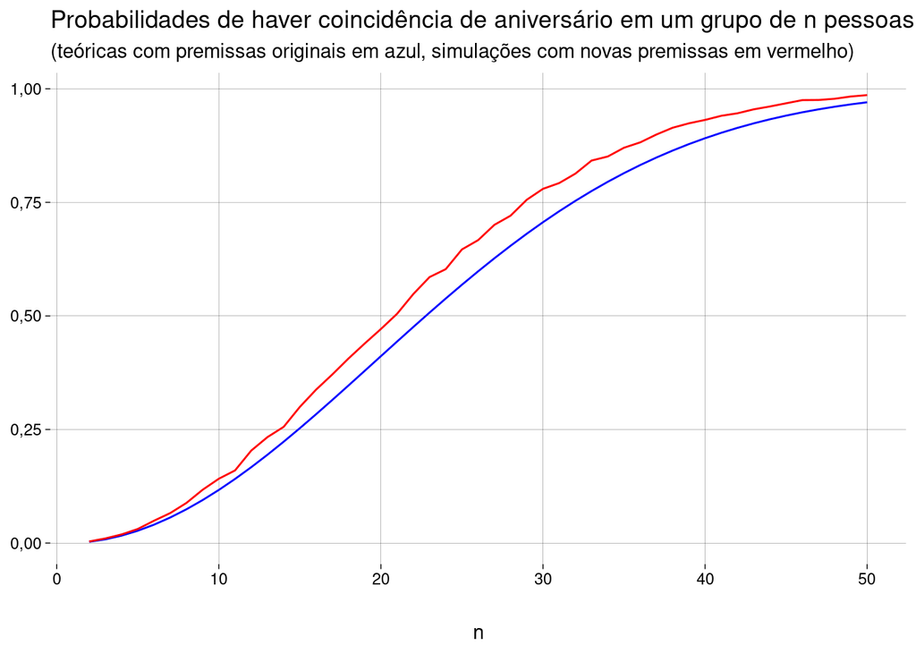

  ```r
  nsalas <- 1e4
  npessoas <- 2:50

  # Probabilidades teóricas
  p <- function(n) {

    1 - prod((364:(366 - n))/365)

  }

  probs <- sapply(npessoas, p)

  grafico <- probs %>%
    as_tibble() %>%
    ggplot(aes(x = npessoas, y = value)) +
      geom_line(color = 'blue') +
      labs(
        title = 'Probabilidades de haver coincidência de aniversário em um grupo de n pessoas',
        y = NULL,
        x = 'n'
      )

  # Probabilidades com 15 semanas com 50% dos nascimentos
  pesos <- c(
    rep(50/105, 105),    # dias das semanas com mais nascimentos
    rep(50/260, 260)     # dias das semanas normais
  )

  coincidencia <- function(sala) {

    !(length(unique(sala)) == length(sala))

  }

  testar_sala <- function(npessoas, pesos) {

    sala <- sample(1:365, npessoas, replace = TRUE, prob = pesos)
    coincidencia(sala)

  }

  simular <- function(npessoas, nsalas, pesos) {

    resultados <- replicate(nsalas, testar_sala(npessoas, pesos))
    mean(resultados)

  }

  novas_probs <- sapply(npessoas, simular, nsalas, pesos)

  grafico +
    geom_line(
      data = as_tibble(novas_probs),
      mapping = aes(y = value),
      color = 'red'
    ) +
    labs(
      subtitle = '(teóricas com premissas originais em azul, simulações com novas premissas em vermelho)'
    )
  ```

## 3.3 Pôquer

Uma mão de pôquer consiste de 5 cartas retiradas ao acaso de um baralho de 32 cartas (4 naipes, cada um com cartas 7, 8, 9, 10, J, Q, K, A).

Calcule as seguintes probabilidades teoricamente e através de simulações.

1. Qual a probabilidade de obter uma mão sem ases?

### Solução

#### Teórica

- A ordem das cartas não importa.
- Basta calcular o número de mãos possíveis usando as $28$ cartas que não são ases:
  $${28 \choose 5} = 98.280$$
- E dividir pelo total de mão possíveis:
  $${32 \choose 5} = 201.376$$
- O resultado é $0{,}49$.

#### Simulação

- Criando as cartas:

  ```r
  baralho <- expand_grid(
    numero = c(7:10, 'J', 'Q', 'K', 'A'),
    naipe = c('♥', '♦', '♣', '♠')
  ) %>%
    mutate(carta = paste(numero, naipe)) %>%
    pull(carta)
  ```

- Função para gerar uma mão:

  ```r
  mao <- function(){
    sample(baralho, size = 5)
  }
  ```

- Testar se tem (pelo menos) um ás:

  ```r
  tem_as <- function(mao) {

    any(str_starts(mao, 'A'))

  }
  ```

- Simulação:

  ```r
  nsim <- 1e6
  maos <- rerun(nsim, mao())

  mean(!map_lgl(maos, tem_as))
  ```

  ```
  ## [1] 0,488401
  ```

2. Qual a probabilidade de obter 4 ases?

### Solução

#### Teórica

- A ordem das cartas não importa.
- Existe uma mão com $4$ ases para cada uma das outras $28$ cartas.
- Logo, a resposta é
  $$\frac{28}{201.376} = 0{,}00$$

#### Simulação

- Testar se tem $4$ ases:

  ```r
  tem_4_ases <- function(mao) {

    sum(str_starts(mao, 'A')) == 4

  }
  ```

- Simular:

  ```r
  mean(map_lgl(maos, tem_4_ases))
  ```

  ```
  ## [1] 0,000129
  ```

3. Qual a probabilidade de obter uma sequência (7 a J, 8 a Q, 9 a K, ou 10 a A) de naipes quaisquer?

### Solução

#### Teórica

- São $4$ possibilidades para o primeiro número da sequência ($7, 8, 9, 10$).
- Cada uma das $5$ cartas pode ter um de $4$ naipes, dando $4^5$ possibilidades.
- Então, existem $4^6 = 4.096$ sequências.
- A resposta é
  $$\frac{4.096}{201.376} = 0{,}02$$

#### Simulação

- Testar se tem sequência:

  ```r
  tem_seq <- function(mao) {

    all(c(7, 8, 9, 1, 'J') %in% str_sub(mao, 1, 1)) ||
    all(c(8, 9, 1, 'J', 'Q') %in% str_sub(mao, 1, 1)) ||
    all(c(9, 1, 'J', 'Q', 'K') %in% str_sub(mao, 1, 1)) ||
    all(c(1, 'J', 'Q', 'K', 'A') %in% str_sub(mao, 1, 1))

  }
  ```

- Simular:

  ```r
  mean(map_lgl(maos, tem_seq))
  ```

  ```
  ## [1] 0,020555
  ```

4. Qual a probabilidade de obter uma sequência (7 a J, 8 a Q, 9 a K, ou 10 a A) do mesmo naipe?

### Solução

#### Teórica

- Cada naipe tem $4$ sequências possíveis.
- O total de sequências, então, é $16$.
- A resposta é
  $$\frac{16}{201.376} = 0{,}00$$
- É mais improvável obter uma sequência do mesmo naipe do que obter $4$ ases.

#### Simulação

- Testar se tem sequência do mesmo naipe:

  ```r
  tem_seq_naipe <- function(mao) {

    tem_seq(mao) && (
      all(str_ends(mao, '♥')) ||
      all(str_ends(mao, '♦')) ||
      all(str_ends(mao, '♠')) ||
      all(str_ends(mao, '♣'))
    )

  }
  ```

- Simular:

  ```r
  mean(map_lgl(maos, tem_seq_naipe))
  ```

  ```
  ## [1] 0,000074
  ```

## 3.4 Dados

Calcule as seguintes probabilidades teoricamente e através de simulações.

1. Você lança um dado não-viciado 6 vezes. Qual a probabilidade de que saiam os 6 números?

### Solução

#### Teórica

- Existem $6 \cdot 6 \cdot 6 \cdot 6 \cdot 6 \cdot 6 = 6^6$ sequências possíveis com os resultados de $6$ dados.
- Existem $6!$ sequências contendo os $6$ números.
- A probabilidade é
  $$\frac{6!}{6^6} = \frac{720}{46.656} = 0{,}02$$

#### Simulação

- Lançar e testar:

  ```r
  nsim <- 1e6

  # Função genérica:
  # n é o número de lançamentos
  # p é um vetor com as probabilidades de cada resultado
  lancar_e_testar_n_dados <- function(n, p) {

    dado <- 1:6
    resultado <- sample(dado, size = n, prob = p, replace = TRUE)
    all(dado %in% resultado)

  }

  simulacao <- replicate(nsim, lancar_e_testar_n_dados(6, rep(1/6, 6)))

  mean(simulacao)
  ```

2. Idem, se você lançar o dado 10 vezes.

#### Teórica

- Existe um total de $6^{10} = 60.466.176$ sequências possíveis com os resultados de $10$ dados.
- Calcular a quantidade de sequências onde aparecem todos os $6$ números não é tão simples assim. Abordagens que parecem corretas acabam errando, contando a mesma sequência mais de uma vez. Precisamos abstrair o problema para a linguagem das funções:

#### Abstração

- O conjunto das posições na sequência é $A = \{1, 2, 3, 4, 5, 6, 7, 8, 9, 10 \}$.
- O conjunto de resultados de um dado é $B = \{1, 2, 3, 4, 5, 6\}$.
- Cada sequência de $10$ resultados é uma função de $f : A \to B$, onde $f(n) = {}$ o resultado do $n$-ésimo dado.
- Cada sequência onde aparecem todos os $6$ valores é uma função *sobrejetora* de $A$ para $B$ (sobrejetora = todo elemento de $B$ é imagem de alguém de $A$).
- Logo, a quantidade de sequências com todos os $6$ números é igual à quantidade de funções sobrejetoras de um conjunto de $10$ elementos para um conjunto de $6$ elementos.
- O livro usado na disciplina de Análise Combinatória, na seção $3.1$ (página $33$ [deste pdf](https://drive.google.com/file/d/0B4pBGM5DQjZUdmxQanVOSmhMY1k/)), explica o *princípio de inclusão-exclusão*, necessário para resolver este problema. O exercício $5$ dessa seção propõe o problema de calcular a quantidade de funções sobrejetoras entre dois conjuntos. A resposta está na página $87$ [deste outro pdf](https://drive.google.com/file/d/0B4pBGM5DQjZUcnJhUlY1Z1JxQm8/).
- No nosso caso, com $|A| = 10$ e $|B| = 6$, a resposta é
  $$\sum_{k=0}^6 (-1)^k {6 \choose k} (6 - k)^{10}$$
- Resolvendo:

  ```r
  parcela <- function(k) {

    (-1)^k * choose(6, k) * (6 - k)^10

  }

  n_todos_6 <- sum(parcela(0:6))
  n_todos_6
  ```

  ```
  ## [1] 16435440
  ```

- A probabilidade é
  $$\frac{16.435.440}{60.466.176} = 0{,}27$$

#### Simulação

- Usando a função definida no item anterior desta questão:

  ```r
  nsim <- 1e6
  simulacao <- replicate(nsim, lancar_e_testar_n_dados(10, rep(1/6, 6)))

  mean(simulacao)
  ```

  ```
  ## [1] 0,271616
  ```

3. Repita os 2 itens acima, para um dado viciado, no qual
   $$P(1) = \frac{1}{12}, \quad P(2) = P(3) = P(4) = P(5) = \frac{1}{6}, \quad P(6) = \frac{3}{12}$$

### Solução

#### Teórica (6 dados)

- Como os lançamentos são independentes, a probabilidade de uma sequência de $6$ lançamentos conter os $6$ números é
  $$P(1) \cdot P(2) \cdot P(3) \cdot P(4) \cdot P(5) \cdot P(6)$$
  multiplicado pela quantidade de permutações dos $6$ números (pois as sequências são mutuamente exclusivas):

  ```r
  probs <- c(1/12, rep(1/6, 4), 3/12)
  prod(probs) * factorial(6)
  ```

  ```
  ## [1] 0,01157407
  ```

#### Simulação (6 dados)

- Simular:

  ```r
  nsim <- 1e6
  probs <- c(1/12, rep(1/6, 4), 3/12)

  simulacao <- replicate(nsim, lancar_e_testar_n_dados(6, probs))

  mean(simulacao)
  ```

  ```
  ## [1] 0,011409
  ```

#### Teórica (10 dados)

- Com estas probabilidades não-uniformes, as sequências de resultados não têm mais probabilidades iguais, e não podemos resolver os problemas apenas contando as quantidades de sequências.
- Provavelmente a única maneira de resolver esta questão teoricamente vai exigir considerarmos um número grande de casos separadamente.
- Em vez disso, vamos resolver usando o R, via um método força bruta, que consiste em gerar todas as sequências possíveis (via um [*iterador*](https://pt.wikipedia.org/wiki/Iterador), para não estourar a memória) e somar as probabilidades das que satisfazem a condição (ter os $6$ números).
- Isto *não* é uma simulação. Não estamos sorteando nada, mas sim percorrendo o espaço de todas as sequências possíveis. A solução é exata.
- No meu computador, com um Intel Core i7 2.20GHz e uma NVidia GeForce GTX 1050, este *chunk* demorou $10$ minutos para rodar.

  ```r
  library(RcppAlgos)

  probs <- c(1/12, rep(1/6, 4), 3/12)
  resposta <- 0

  sequencia <- permuteIter(6, 10, repetition = TRUE)

  s <- sequencia$nextIter()

  while(!isFALSE(s)) {

    if (all(1:6 %in% s)) {
      resposta <- resposta + prod(probs[s])
    }

    s <- sequencia$nextIter()

  }
  ```

  ```
  ## No more results. To see the last result, use the prevIter method(s)
  ```

  ```r
  resposta
  ```

  ```
  ## [1] 0,2082742
  ```

#### Simulação (10 dados)

- Simular:

  ```r
  nsim <- 1e6
  probs <- c(1/12, rep(1/6, 4), 3/12)

  simulacao <- replicate(nsim, lancar_e_testar_n_dados(10, probs))

  mean(simulacao)
  ```

  ```
  ## [1] 0,209246
  ```